# **Teste Qui-quadrado de Homogeneidade**

Guilherme Furtado, Gustavo Belfort, Gustavo Nishijima, Keila Mara

25/06/2025

# 1 Teoria

**O que é:** o teste Qui-quadrado de Homogeneidade é um dos três tipos de comparações realizadas pelo teste não paramétrico “Teste Qui-quadrado de Pearson”.

**Objetivo:** investigar se uma determinada variável qualitativa $Y$ com $k$ categorias se distribui de forma homogênea em $s$ subpopulações de interesse $(s \ge 2)$ definidas por outra variável qualitativa $X$.

**Exemplos de análises para as quais deve-se usar o teste qui-quadrado de homogeneidade:**

1. Para verificar se a preferência da Área de Conhecimento é a mesma entre alunos de sexo Feminino e sexo Masculino $(Y$: Área do Conhecimento; $X$: Sexo$).$
2. Para verificar se as preferências partidárias são as mesmas entre diferentes bairros $(Y$: Preferência Partidária; $X$: Bairro$).$
3. Para verificar se a escolha de atividades de alunos do Ensino Médio tem mudado de classe para classe $(Y$: Atividade; $X$: Classe do Ensino Médio$).$

**Princípio básico usado na execução do teste:** Comparar proporções, analisando possíveis divergências entre as frequências observadas e as frequências esperadas para um certo evento de $Y$ nos $s$ subgrupos que definem as subpopulações de interesse.

## 1.1 Execução Prática do Teste

**Passo 1:** Coleta-se dados conjuntamente das variáveis $X$ e $Y$ para uma amostra de tamanho de $N$.

**Passo 2:** Constrói-se uma tabela de contingência, também chamada de tabela cruzada das variáveis $X$ e $Y$, a partir da contagem de elementos dos dados que estão conjuntamente em cada uma das $k$ categorias da variável $Y$ e em cada uma das $s$ sub-amostras definidas pelas categorias de $X$. Tais contagens são chamadas de **frequências observadas**.

A Tabela cruzada de uma variável $Y$ com $k$ categorias e uma variável $X$ que define $s$ subpopulações de interesse, com as frequências observadas, fica assim definida:

| Subpopulações | Categorias de Y 1 | Categorias de Y 2 | Categorias de Y … | Categorias de Y k | Total |
| --- | --- | --- | --- | --- | --- |
| 1 | $O_{11}$ | $O_{12}$ | … | $O_{1k}$ | $r_1$ |
| 2 | $O_{21}$ | $O_{22}$ | … | $O_{2k}$ | $r_2$ |
| ⋮ |  |  |  |  |  |
| s | $O_{s1}$ | $O_{s2}$ | … | $O_{sk}$ | $r_s$ |
| Total | $c_1$ | $c_2$ | … | $c_k$ | N |

onde

$O_{ij}=$ frequência observada da $i-$ésima linha e $j-$ésima coluna, $1 \le i \le s$ e $1 \le j \le k$

ou seja,

$O_{ij}=$= número de elementos da amostra que tem variável $X$ na $i-$ésima categoria e variável $Y$ na $j-$ésima categoria.

**Passo 3:** Calcula-se as **frequências esperadas** em cada possível cruzamento $ij$ das variáveis $X$ e $Y$ definidas por

$$E_{ij} = \frac {r_ic_j}{N},$$
onde,

$r_i=$ total de elementos na $i-$ésima linha, $1 \le i \le s$;

$c_j=$ total de elementos na $j-$ésima coluna, $1 \le j \le k$.

**Passo 4:** Executa-se o teste qui quadrado abaixo definido.

## 1.2 Definição Estatística do Teste

Um teste de significância estatística está bem definido se forem definidos: as hipóteses do teste, a estatística de teste, a distribuição amostral da estatística de teste, o nível de significância adotado e a regra de decisão do teste.

### 1.2.1 Hipóteses do Teste

Dada a j-ésima coluna, definamos a proporção $p_{ij} =$ proporção de casos da $i-$ésima subpopulação que tem variável $Y$ na $j-$ésima categoria.

**H<sub>0</sub>**: Todas as proporções numa mesma coluna $j$ são iguais $(p_{1j} = p_{2j} =· · · = p_{sj} = p_{j} , \forall j)$.

**H<sub>1</sub>**: Pelo menos uma das proporções $p_{ij}$ é diferente de $p_{j}$ para algum $j$.

*ou, equivalentemente,*

**H<sub>0</sub>**: A distribuição da Variável $Y$ é homogênea entre as $s$ subpopulações definidas pela variável $X$

**H<sub>1</sub>**: A distribuição da Variável $Y$ não é homogênea entre as subpopulações definidas pela variável $X$

### 1.2.2 Estatística do Teste

Testamos se as freqüências observadas diferem muito das freqüências esperadas, com base na seguinte estatística:

$$Q^2= \sum_{i=1}^s \sum_{j=1}^k
\frac{(O_{ij}-E_{ij})^2}{E_{ij}}$$
Quanto maior o valor de $Q^2$ maior será a probabilidade de as frequências observadas estarem divergindo das freqüências esperadas.

### 1.2.3 Distribuição da Estatística do Teste

Sob a hipótese nula, $Q^2$ tem distribuição $\chi^2$ com $d=(k-1).(s-1)$ graus de liberdade.

### 1.2.4 Regra de Decisão do Teste

Pela estatística de teste: Se $Q^2>\chi^2_{d,\alpha}$, rejeita-se H<sub>0</sub> para o nível de significância α.

Pelo valor-p: Se valor-p for menor que o nível de significância α, rejeita-se H<sub>0</sub> para o nível de significância α.

# 2 Exemplo com Dados Simulados

Em uma escola de Ensino Médio, foi realizada uma pesquisa com 100 alunos para investigar a Área de Conhecimento a ser estudada no futuro de preferência dos alunos. Desejamos conferir se há homogeneidade entre os grupos Feminino e Masculino quanto à Área de Conhecimento de suas preferências.

```r
# Carregamento pacotes
library(knitr)
library(tidyverse)
library(kableExtra)

# Gerar dados fictícios
set.seed(9)
dados <- data.frame(
  id = 1:100,
  sexo = sample(c("Masculino", "Feminino"),
                size = 100,
                replace = TRUE,
                prob = c(0.5, 0.5)),
  preferencia = sample(c('Exatas', 'Humanas'),
                      size = 100,
                      replace = TRUE,
                      prob = c(0.3, 0.7))
)
```

## 2.1 Análise Exploratória

### 2.1.1 Visualização dos Dados

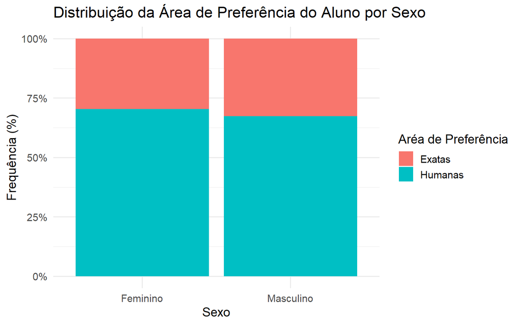

```r
ggplot(dados,aes(x = sexo, fill = preferencia)) +
  geom_bar(position = "fill") +
  labs(x = "Sexo", y = "Frequência (%)",fill = "Aréa de Preferência",title = "Distribuição da Área de Preferência do Aluno por Sexo") +
  scale_y_continuous(labels = scales::percent_format())+
  theme_minimal(base_size = 14)
```

### 2.1.2 Tabela de Contingência com Frequências Observadas

```r
tabela = table(dados$sexo , dados$preferencia)
names(dimnames(tabela)) <- c("Sexo", "Área de Preferência")

#Criando um tabela incluindo os totais

tabela_com_totais=tabela[c("Masculino","Feminino"),]
invisible(capture.output(tabela_com_totais <- addmargins(tabela_com_totais, FUN = sum)))
dimnames(tabela_com_totais)[[1]][length(dimnames(tabela_com_totais)[[1]])] <- "Total"
dimnames(tabela_com_totais)[[2]][length(dimnames(tabela_com_totais)[[2]])] <- "Total"

kable(tabela_com_totais, caption = "Tabela de Contingência com Frequências Observadas") |>
  add_header_above(c("Sexo"=1,"Área de Preferência"=2," "=1)) |>
  kable_styling(bootstrap_options = c("striped", "hover"),
                position = "center",
                full_width = FALSE)
```

Tabela de Contingência com Frequências Observadas

| Sexo | Área de Preferência Exatas | Área de Preferência Humanas | Total |
| --- | --- | --- | --- |
| Masculino | 15 | 31 | 46 |
| Feminino | 16 | 38 | 54 |
| Total | 31 | 69 | 100 |

## 2.2 Teste Qui-Quadrado de Homogeneidade

O teste Qui-quadrado de Homogeneidade avalia se a distribuição de uma variável categórica é a mesma através de diferentes populações.

Neste caso, temos:

**Variável $X$ de Grupo, que define as populações a serem comparadas**: Sexo, com $s=2$ categorias, “Feminino” e “Masculino”;

**Variável $Y$ de Resposta**: Área de Preferência, neste caso com $k=2$ categorias, “Exatas” e “Humanas”

**Hipóteses do Teste:**

**H<sub>0</sub>**: A distribuição da Área de Preferência é homogênea entre os grupos definidos pelo Sexo (Feminino e Masculino)

**H<sub>1</sub>**: A distribuição da Área de Preferência não é homogênea entre os grupos definidos pelo Sexo (Feminino e Masculino)

**Nível de significância**: $\alpha = 5\%$

### 2.2.1 Aplicação do Teste Qui-Quadrado

```r
teste <- chisq.test(tabela)
teste
```

```
##
##  Pearson's Chi-squared test with Yates' continuity correction
##
## data:  tabela
## X-squared = 0.010841, df = 1, p-value = 0.9171
```

### 2.2.2 Tabela de Contigência com Frequências Esperadas

```r
esperado <- round(teste$expected, 2)


#Gerar tabela de frequência Esperada sob H0 com totais

esperado=esperado[c("Masculino","Feminino"),]
invisible(capture.output(esperado <- addmargins(esperado, FUN = sum)))
dimnames(esperado)[[1]][length(dimnames(esperado)[[1]])] = "Total"
dimnames(esperado)[[2]][length(dimnames(esperado)[[2]])] = "Total"

kable(esperado, align = 'c', caption = "Tabela de Contigência com Frequências Esperadas sob H₀") |>
  add_header_above(c("Sexo"=1,"Preferência"=2," "=1)) |>
  kable_styling(bootstrap_options = c("striped", "hover"),
                position = "center",
                full_width = FALSE)
```

Tabela de Contigência com Frequências Esperadas sob H₀

| Sexo | Preferência Exatas | Preferência Humanas | Total |
| --- | --- | --- | --- |
| Masculino | 14.26 | 31.74 | 46 |
| Feminino | 16.74 | 37.26 | 54 |
| Total | 31.00 | 69.00 | 100 |

### 2.2.3 Decisão Estatística e Conclusão

Graus de liberdade $d=(k-1).(s-1)=$ 1

Valor-p: 0.9171

Como o valor-p é maior que o nivel de significância α = 0.05, não rejeitamos a hipótese nula. Não há evidências suficientes para afirmar que a distribuição da Área de Preferência difere entre as categorias de Sexo.

## 2.3 Considerações Finais

A análise visual sugere maior preferência pela Área de Humanas no grupo Feminino e o teste qui-quadrado atestou que as diferenças observadas entre as frequências das Áreas de Preferência dos grupos Feminino e Masculino não são sigificativas sob o ponto de vista estatístico.

Diante o exposto, recomenda-se ampliar o estudo com mais participantes para confirmar os resultados.